# Assignment 2 Dispersed Multiphase Flow (ME5310)

Shahil Chaudhari(ME21M038)

## Que1: Plot the number histogram of particle size distribution for 2, 10, 20 and 30 number of bins.

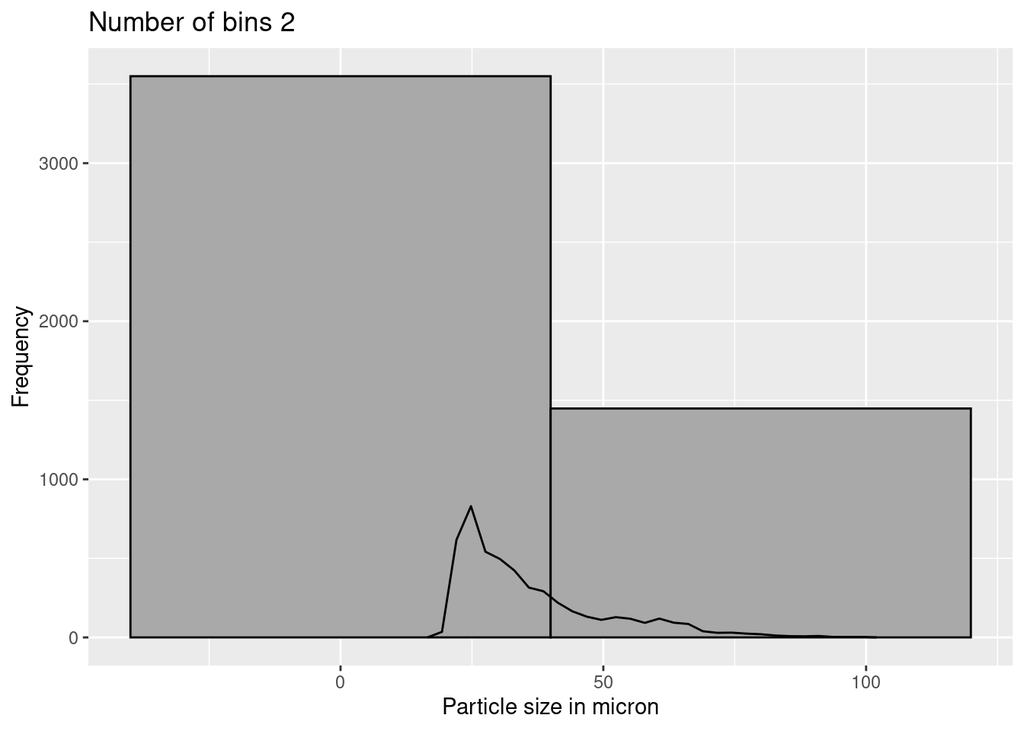

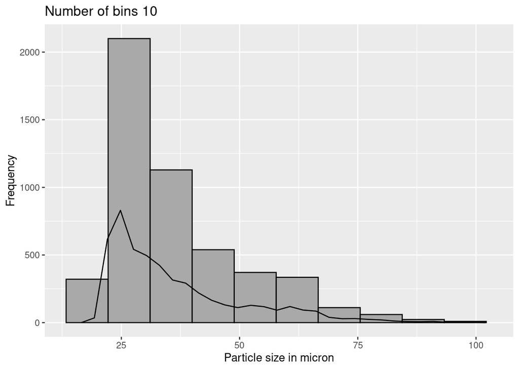

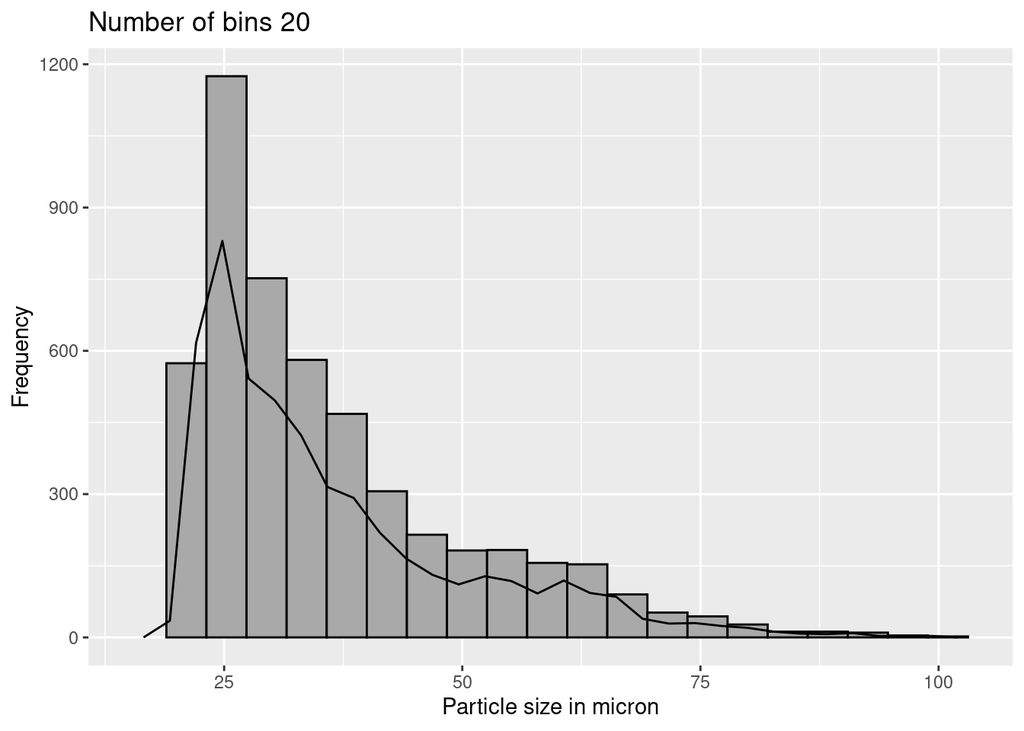

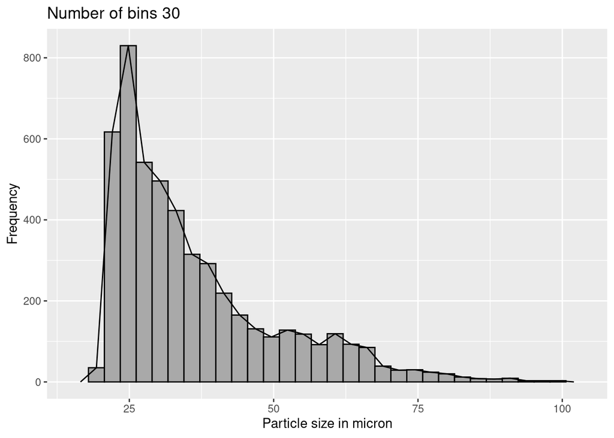

## Que 2: Plot the number probability distribution for the above cases. Mention your observation on the effect of increasing the number of bins.

##### From Graphs we can see that as bin size increases distribution becomes clear. Probability distribution is linear when Bin size is 2. When bin size is 10 we cannot see the sudden increase in frequency from 19.9 micron to 25 micron size because high frequency dominates over low frequency.

##### Though high bin size is better but it will create problem when compared with standard distribution for analysis. It is important to choose appropriate bin size.

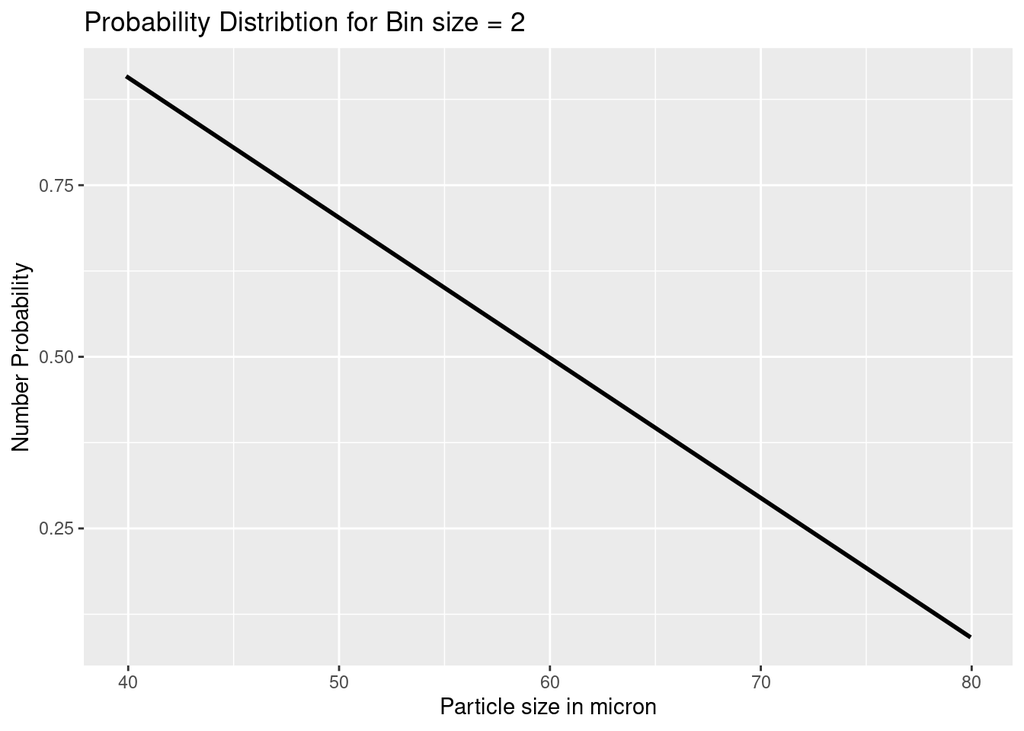

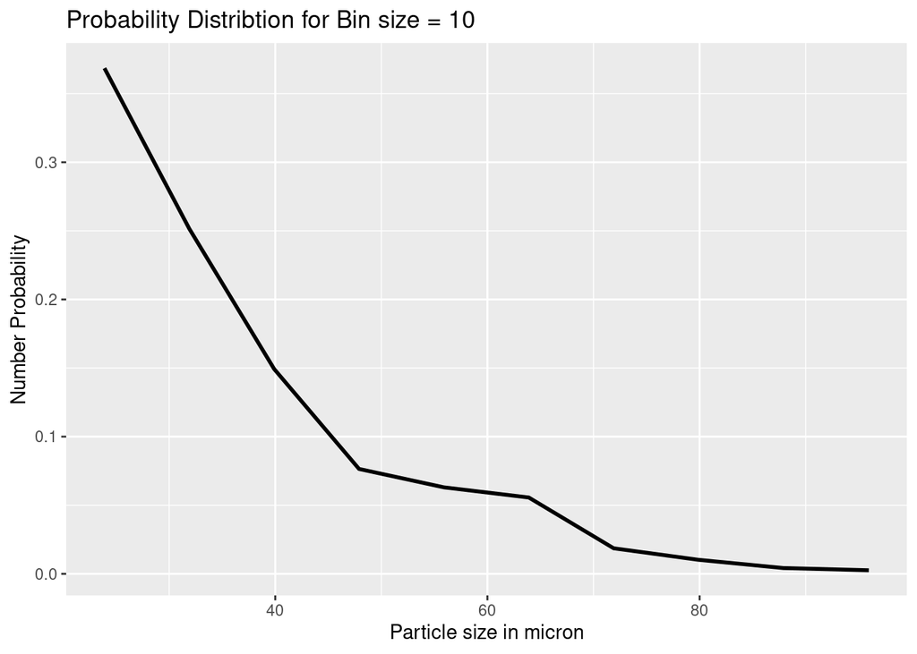

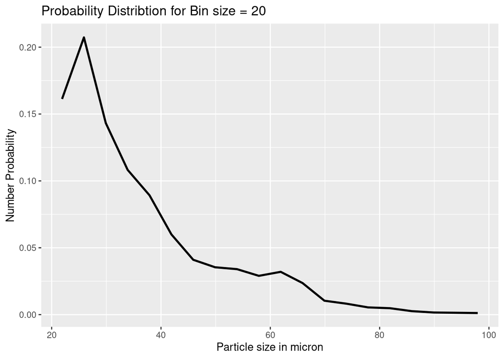

[figure not shown]

## Que 3: If particle sizing accuracy is 3 microns, select a bin size that you would prefer to represent the particle size distribution.

##### Ans:-

#### Bin size ——> Range of Diameter

##### 2 ——-> 40 micron

##### 10 ——-> 8 micron

##### 20 ——-> 4 micron

##### 30 ——-> 2 micron

##### For bins size above 20 diameter range is below 4 micron so it is not advisable for accuracy perspective (3 micron) because it is possible that particle may be in adjacent bin but due to measurement accuracy particle is counted in that particular bin. I plotted Rossin-Rammler distribution for every bin size and found that log-log curve is more linear below bin size = 20. For other bin size the curve is polynomial so I choose this bin size for further calculation

## I) (a) cumulative number probability distribution (b) cumulative mass probability distribution

##### Ans: -

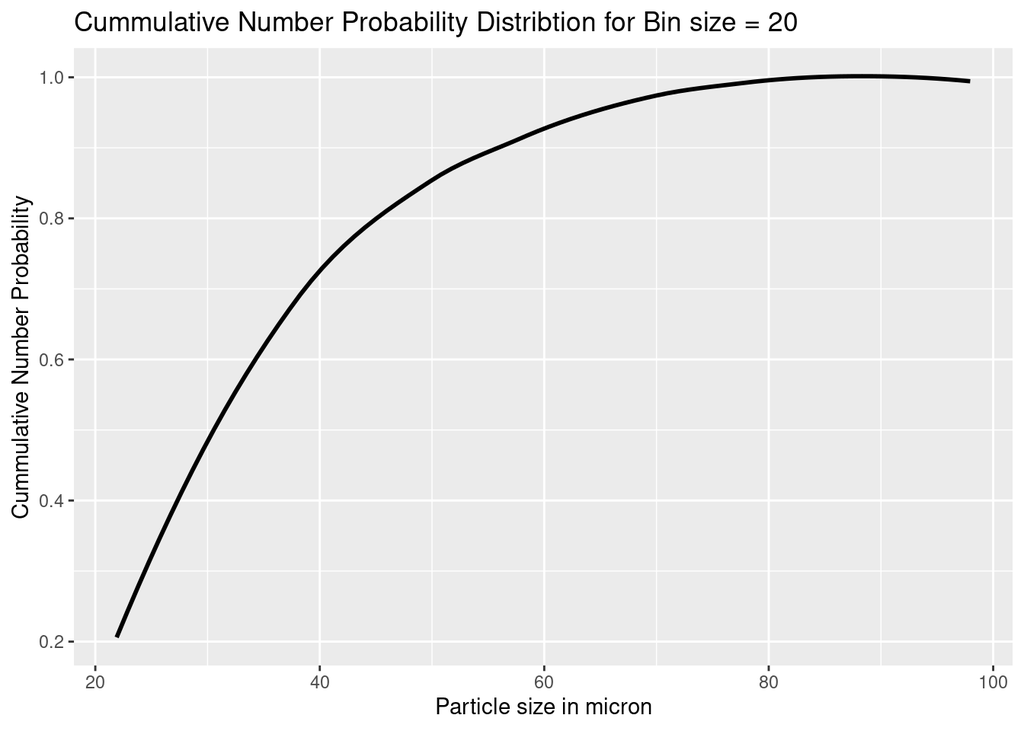

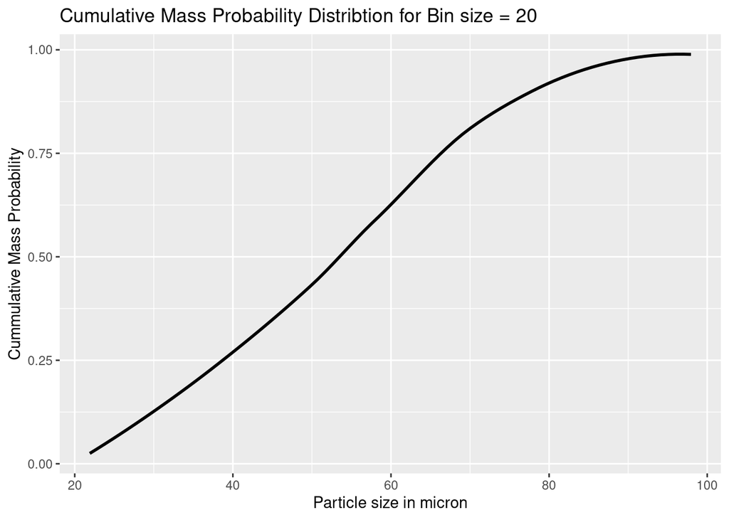

## IV) Find the shape and scale parameters of a Rossin-Rammler distribution that can represent the above size distribution.

##### Ans:-

##### While ploting Rossin-Rammler Distribution log-log curve I removed last bin because of range (96 to 100) because at that bin log(-log(1-F(d))) value(cummulative probability =1) is infinite so I took only 19 points to fit curve.

##### To get values of dnm(Median Number diameter) and dmm(Median mass diameter) I use interpolation

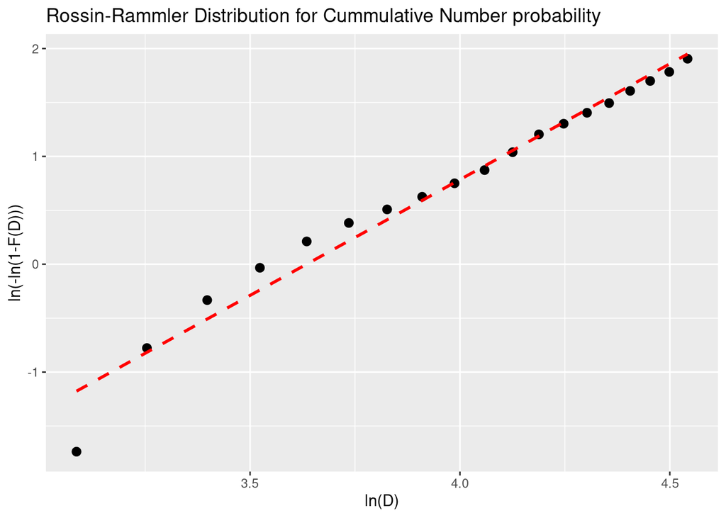

#### ** ln(-ln(1-F(D))) = 2.1477194* ln(D) -7.8058071 **

##### Shape Parameter(η) = 2.1477194

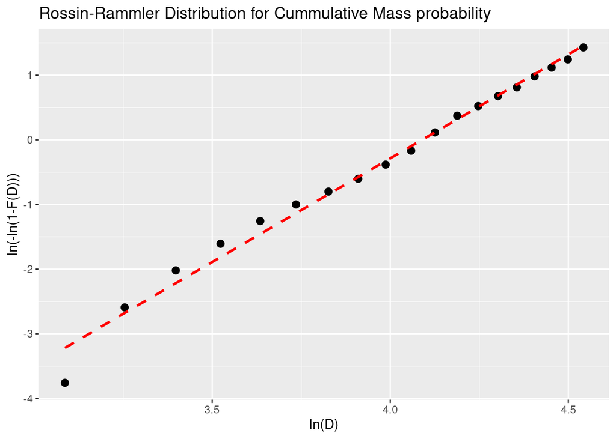

## Que 4: The minimum and maximum particle size in a one-dimensional transport of water droplets in air flow are 10 microns and 100 microns, respectively, when considered within a given sample volume (1 m3). The particle number density function and particle velocity distribution are assumed to be linear as depicted in Fig

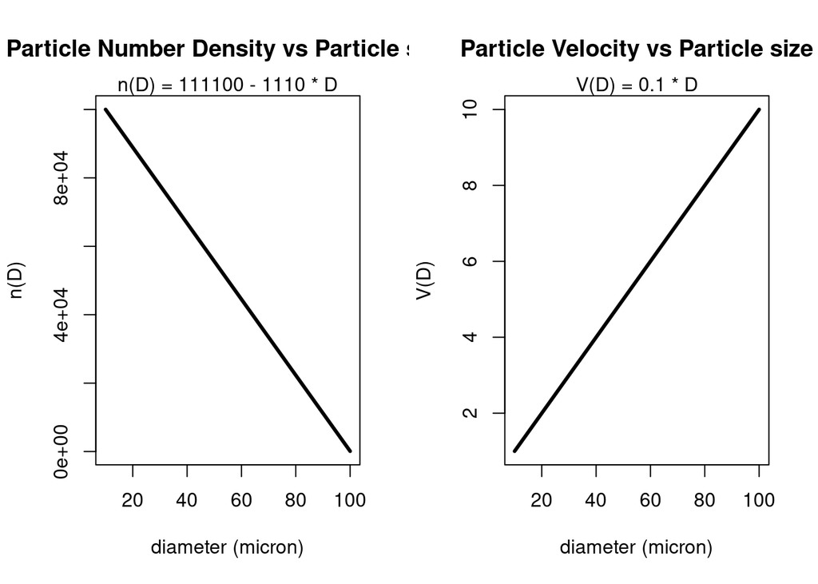

## (a) number density of all particles, (b) particle volume fraction (c) particle bulk density (d) particle mass flux in the flow direction

#### D1 = 10 micron

#### D2 = 100 micron

$\Delta V = 1 \; m^ {3}$  
$N(D) = -1110\;D + 111100$ $\;\;\;\;V(D)= 0.1 \;D$

#### (a) Number density of all particles

$\Delta n = \int_{D1}^{D2} n(D) \; dD$

$\ = \int_{10}^{100} -1110D + 111100 \; dD$

$\ =(\left. -1110\;\frac{D^{2}}{2} +111100\;D\right)|_{10}^{100}$

#### (b) Particle volume fraction

$\ Particle \;volume\; fraction \; \alpha_{d} = \frac{\Delta V_{d}}{\Delta V}$

$\Delta V_d= \int_{10}^{100} (-1110D + 111100)\;\frac{\pi \; D^{3}}{6} \; dD$

$\ = \frac{\pi}{6}\int_{10}^{100} (-1110\;D^{4} + 111100\;D^{3}) \; dD$

$\ = \frac{\pi}{6}\ (\left. -1110\;\frac{D^{5}}{5} +111100\;\frac{D^{4}}{4}\right)|_{10}^{100}$

$\ = \frac{\pi}{6}\ (\left. -1110\;\frac{100^{5}-10^{5}}{5} +111100\;\frac{100^{4}-10^{4}}{4}\right)$

#### (c) Particle bulk density

$\ Water Density \;(\;\rho_d\;) = 1000 \; \frac{kg}{m^3}$

$\ Particle Bulk Density \; (\;\overline{\rho_d}\;) = \rho_{d} \; \alpha_{d}$

#### (d) Particle Mass flux in flow direction

$\ Mass \;flow\; rate \; (\dot{m}_{d}) = \int_{D1}^{D2} n(D) \;V(D) \; \rho_d \frac{\pi\;D^3}{6}\; dD$

$\ = \int_{10}^{100} (-1110\;D + 111100)(0.1 \;D) \;1000\; \frac{\pi D^3}{6} dD$

$\ = \frac{100 \;\pi}{6}\int_{10}^{100} (-1110\;\ D^5 + 111100\; D^4) \; dD$

$\ = \frac{100\;\pi}{6}\ (\left. -1110\;\frac{D^{6}}{6} +111100\;\frac{D^{5}}{5}\right)|_{10}^{100}$

$\ = \frac{100\;\pi}{6}\ (\left. -1110\;\frac{100^{6}-10^{6}}{6} +111100\;\frac{100^{5}-10^{5}}{5}\right)$